# Geocoding

Samuel Lippl

12 September 2018

This document geocodes the countries in the V-DEM dataset beginning in 1946. We therefore extract the necessary part of the dataset:

```r
df_geocode <-
  df_vdem %>%
  filter(year >= 1946) %>%
  select(country_name, COWcode) %>%
  unique()
df_geocode
```

```
## # A tibble: 186 x 2
##    country_name         COWcode
##    <chr>                  <dbl>
##  1 Afghanistan              700
##  2 Angola                   540
##  3 Albania                  339
##  4 United Arab Emirates     696
##  5 Argentina                160
##  6 Armenia                  371
##  7 Australia                900
##  8 Austria                  305
##  9 Azerbaijan               373
## 10 Burundi                  516
## # ... with 176 more rows
```

Of course, country borders change. This is where the package `cshapes` is helpful.

```r
cshp <-
  cshp() %>%
  st_as_sf()
head(cshp)
```

```
## Simple feature collection with 6 features and 24 fields
## geometry type:  MULTIPOLYGON
## dimension:      XY
## bbox:           xmin: -175.36 ymin: -21.26806 xmax: -53.98612 ymax: 12.1975
## epsg (SRID):    4326
## proj4string:    +proj=longlat +ellps=WGS84 +no_defs
##            CNTRY_NAME        AREA       CAPNAME CAPLONG     CAPLAT
## 0              Guyana 211982.0050    Georgetown   -58.2   6.800000
## 1            Suriname 145952.2740    Paramaribo   -55.2   5.833333
## 2 Trinidad and Tobago   5041.7290 Port-of-Spain   -61.5  10.650000
## 3           Venezuela 916782.2172       Caracas   -66.9  10.500000
## 4               Samoa   2955.2124          Apia  -172.0 -13.800000
## 5               Tonga    464.7473    Nuku'alofa  -175.0 -21.100000
##   FEATUREID COWCODE COWSYEAR COWSMONTH COWSDAY COWEYEAR COWEMONTH COWEDAY
## 0         0     110     1966         5      26     2016         6      30
```

[output cut: 26 more lines]

We only need the COW Codes, not the GW Codes. “COWSYEAR” refers to the first year of coding and COWEYEAR of coding. As we need years, we will refer to the old borders if the coding ends after the 1st January of the corresponding year:

```r
cshp <-
  cshp %>%
  transmute(country = CNTRY_NAME,
            cow_code = as.numeric(COWCODE),
            start_year = if_else(
              COWSMONTH == 1 & COWSDAY == 1,
              as.numeric(COWSYEAR),
              COWSYEAR + 1
            ),
            end_year = if_else(
              COWEMONTH == 1 & COWEDAY == 1,
              COWEYEAR - 1,
              as.numeric(COWEYEAR)
            ))
cshp
```

```
## Simple feature collection with 255 features and 4 fields
## geometry type:  MULTIPOLYGON
## dimension:      XY
## bbox:           xmin: -180 ymin: -55.90223 xmax: 180 ymax: 83.11387
## epsg (SRID):    4326
## proj4string:    +proj=longlat +ellps=WGS84 +no_defs
## First 10 features:
##                country cow_code start_year end_year
## 1               Guyana      110       1967     2016
## 2             Suriname      115       1976     2016
## 3  Trinidad and Tobago       52       1963     2016
## 4            Venezuela      101       1946     2016
## 5                Samoa      990       1977     2016
## 6                Tonga      955       2000     2016
## 7            Argentina      160       1946     2016
## 8              Bolivia      145       1946     2016
## 9               Brazil      140       1961     2016
## 10               Chile      155       1946     2016
##                          geometry
## 1  MULTIPOLYGON (((-58.17262 6...
## 2  MULTIPOLYGON (((-55.12796 5...
## 3  MULTIPOLYGON (((-61.07945 1...
## 4  MULTIPOLYGON (((-66.31029 1...
## 5  MULTIPOLYGON (((-172.5965 -...
## 6  MULTIPOLYGON (((-175.1453 -...
## 7  MULTIPOLYGON (((-71.85916 -...
## 8  MULTIPOLYGON (((-62.19884 -...
## 9  MULTIPOLYGON (((-44.69501 -...
## 10 MULTIPOLYGON (((-73.0421 -4...
```

Furthermore, I extend the `end_year` column to 2017 so that the latest year of V-DEM data can be included.

```r
cshp <-
  cshp %>%
  mutate(end_year = if_else(end_year == 2016, 2017, end_year))
```

We can now join the two data frames:

```r
cow_geocode <-
  cshp %>%
  inner_join(df_geocode, by = c("cow_code" = "COWcode"))
cow_geocode %>%
  unique()
```

```
## Simple feature collection with 224 features and 5 fields
## geometry type:  MULTIPOLYGON
## dimension:      XY
## bbox:           xmin: -180 ymin: -55.90223 xmax: 180 ymax: 83.11387
## epsg (SRID):    4326
## proj4string:    +proj=longlat +ellps=WGS84 +no_defs
## First 10 features:
##                country cow_code start_year end_year        country_name
## 1               Guyana      110       1967     2017              Guyana
## 2             Suriname      115       1976     2017            Suriname
## 3  Trinidad and Tobago       52       1963     2017 Trinidad and Tobago
## 4            Venezuela      101       1946     2017           Venezuela
## 5            Argentina      160       1946     2017           Argentina
## 6              Bolivia      145       1946     2017             Bolivia
## 7               Brazil      140       1961     2017              Brazil
## 8                Chile      155       1946     2017               Chile
## 9              Ecuador      130       1946     2017             Ecuador
## 10            Paraguay      150       1946     2017            Paraguay
##                          geometry
## 1  MULTIPOLYGON (((-58.17262 6...
## 2  MULTIPOLYGON (((-55.12796 5...
## 3  MULTIPOLYGON (((-61.07945 1...
## 4  MULTIPOLYGON (((-66.31029 1...
## 5  MULTIPOLYGON (((-71.85916 -...
## 6  MULTIPOLYGON (((-62.19884 -...
## 7  MULTIPOLYGON (((-44.69501 -...
## 8  MULTIPOLYGON (((-73.0421 -4...
## 9  MULTIPOLYGON (((-79.45167 -...
## 10 MULTIPOLYGON (((-57.67267 -...
```

We also retain the rows in `cshp` and `df_geocode` that could not be matched:

```r
vdem_rem <-
  df_geocode %>%
  anti_join(cshp, by = c("COWcode" = "cow_code"))
cshp_rem <-
  cshp %>%
  anti_join(df_geocode, by = c("cow_code" = "COWcode"))
```

```r
vdem_rem %>%
  unique()
```

```
## # A tibble: 6 x 2
##   country_name              COWcode
##   <chr>                       <dbl>
## 1 Hong Kong                   99999
## 2 Palestine/British Mandate   99999
## 3 Palestine/West Bank         99999
## 4 Palestine/Gaza              99999
## 5 Somaliland                  99999
## 6 Zanzibar                    99999
```

The COWcode for all remaining countries is 99999 which probably encodes `NA`.

```r
cshp_rem %>%
  as_tibble %>%
  select(-geometry) %>%
  print(n = 31)
```

```
## # A tibble: 31 x 4
##    country                        cow_code start_year end_year
##    <fct>                             <dbl>      <dbl>    <dbl>
##  1 Samoa                               990       1977     2017
##  2 Tonga                               955       2000     2017
##  3 Dominica                             54       1979     2017
##  4 Grenada                              55       1975     2017
##  5 St. Lucia                            56       1980     2017
##  6 St. Vincent and the Grenadines       57       1980     2017
##  7 Bahamas                              31       1974     2017
##  8 Belize                               80       1982     2017
##  9 Antigua and Barbuda                  58       1982     2017
## 10 St. Kitts and Nevis                  60       1984     2017
## 11 Andorra                             232       1994     2017
## 12 Monaco                              221       1994     2017
```

[output cut: 19 more lines]

A quick inspection demonstrates that `cshp_rem` is not of use (the USSR and Yugoslavia observations are only encoded for the GW borders for these intervals).

We therefore need to employ a different strategy for this part of the geocoding. The Natural Earth dataset will come in handy.

## Zanzibar

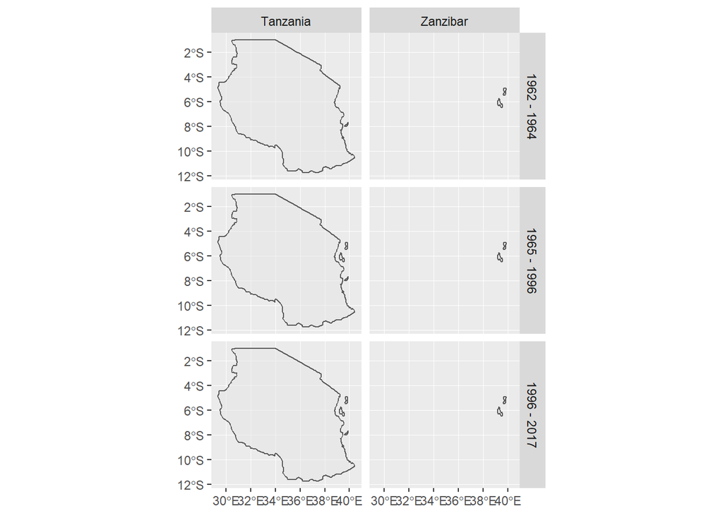

```r
tanzania_62_64 <-
  cshp %>%
  filter(country == "Tanzania", end_year <= 1964) %>%
  select(geometry) %>%
  unique() %>%
  extract2("geometry")
zanzibar <-
  cshp %>%
  filter(country == "Zanzibar") %>%
  extract2("geometry")
tanzania_65_96 <-
  cshp %>%
  filter(country == "Tanzania", start_year >= 1965, end_year == 1996) %>%
  extract2("geometry")
tanzania_97_ <-
  cshp %>%
  filter(country == "Tanzania", start_year == 1997) %>%
  extract2("geometry")
df_ts <- st_sf(
  timespan = c("1962 - 1964", "1962 - 1964",
               "1965 - 1996", "1965 - 1996",
               "1996 - 2017", "1996 - 2017"),
  country = rep(c("Tanzania", "Zanzibar"), 3),
  geometry = c(tanzania_62_64, zanzibar,
               tanzania_65_96, zanzibar,
               tanzania_97_, zanzibar)
)
ggplot(df_ts) +
  geom_sf(alpha = .5) +
  facet_grid(vars(timespan), vars(country))
```

We therefore need to subtract zanzibar from tanzania after 1965:

```r
tanzania_65_96 <-
  tanzania_65_96 %>%
  st_difference(zanzibar)
```

```
## although coordinates are longitude/latitude, st_difference assumes that they are planar
```

```r
tanzania_97_ <-
  tanzania_97_ %>%
  st_difference(zanzibar)
```

```
## although coordinates are longitude/latitude, st_difference assumes that they are planar
```

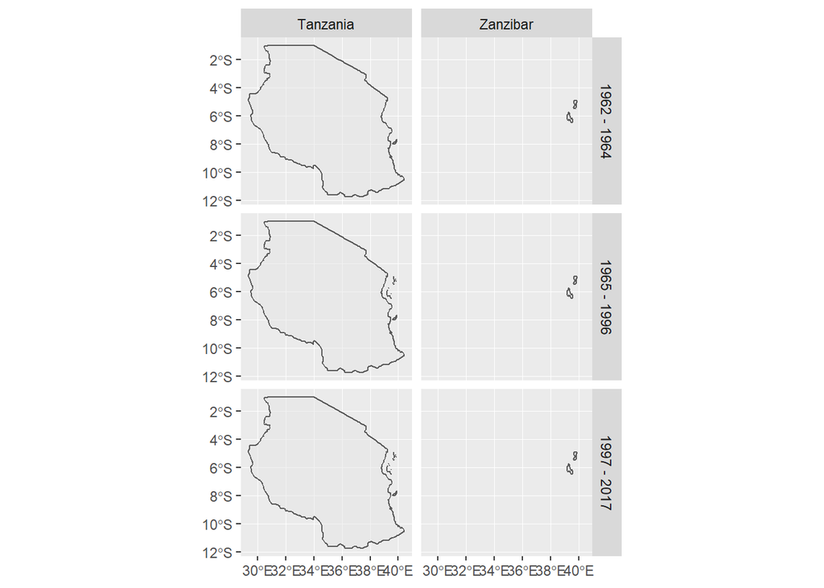

```r
df_ts <- st_sf(
  timespan = c("1962 - 1964", "1962 - 1964",
               "1965 - 1996", "1965 - 1996",
               "1997 - 2017", "1997 - 2017"),
  country = rep(c("Tanzania", "Zanzibar"), 3),
  geometry = c(tanzania_62_64, zanzibar,
               tanzania_65_96, zanzibar,
               tanzania_97_, zanzibar)
)
ggplot(df_ts) +
  geom_sf(alpha = .5) +
  facet_grid(vars(timespan), vars(country))
```

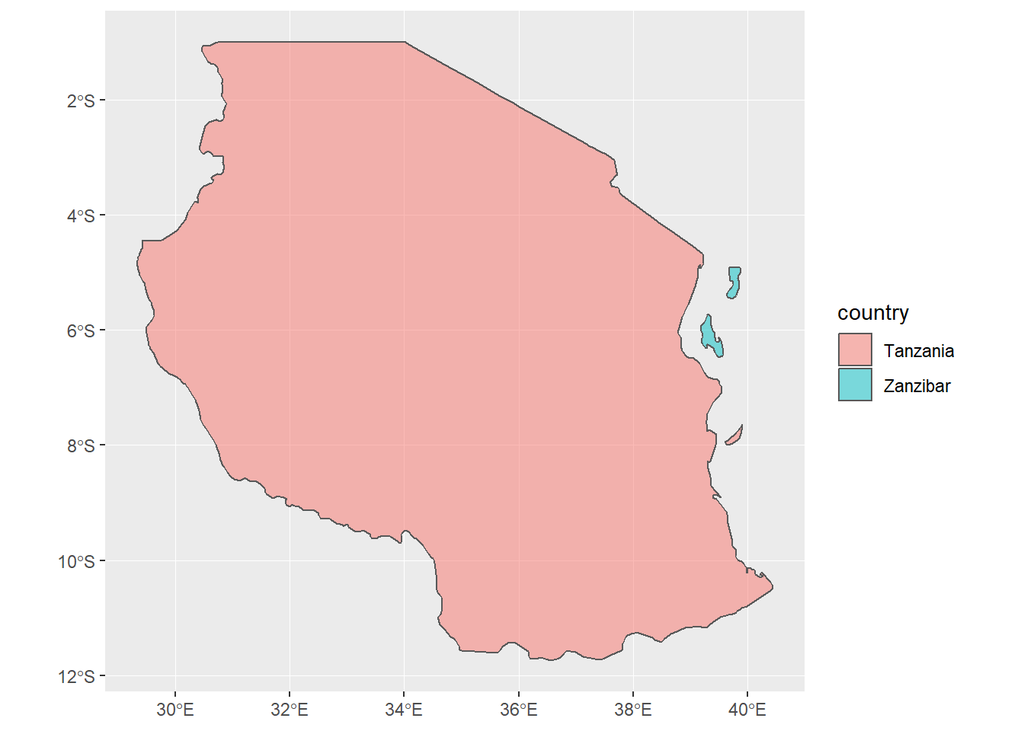

```r
df_ts %>%
  filter(timespan == "1965 - 1996") %>%
  ggplot(aes(fill = country)) +
  geom_sf(alpha = .5)
```

It can be clearly seen here that our operation was successful.

```r
cow_geocode <-
  cow_geocode %>%
  filter(!(country_name == "Tanzania" & start_year >= 1965)) %>%
  rbind(
    st_sf(
      country = c("Tanzania", "Tanzania", "Zanzibar"),
      country_name = c("Tanzania", "Tanzania", "Zanzibar"),
      cow_code = c(510, 510, NA_integer_),
      start_year = c(1965, 1997, 1962),
      end_year = c(1996, 2017, 2017),
      geometry = c(tanzania_65_96, tanzania_97_, zanzibar)
    ) %>%
      st_transform(crs = st_crs(cow_geocode))
  )
```

## Somalia

```r
countries <- read_sf(
  system.file(
    "extdata",
    "natural_earth/ne_110m_admin_0_sovereignty.shp",
    package = "vdem.tectr"
  )
) %>%
  st_transform(st_crs(cshp))
```

Somaliland does not exist in `cshp` and we therefore extract it from the https://www.naturalearthdata.com/. https://www.bbc.com/news/world-africa-14115069 declared independence in 1991 and is coded as a country by the V-Dem since.

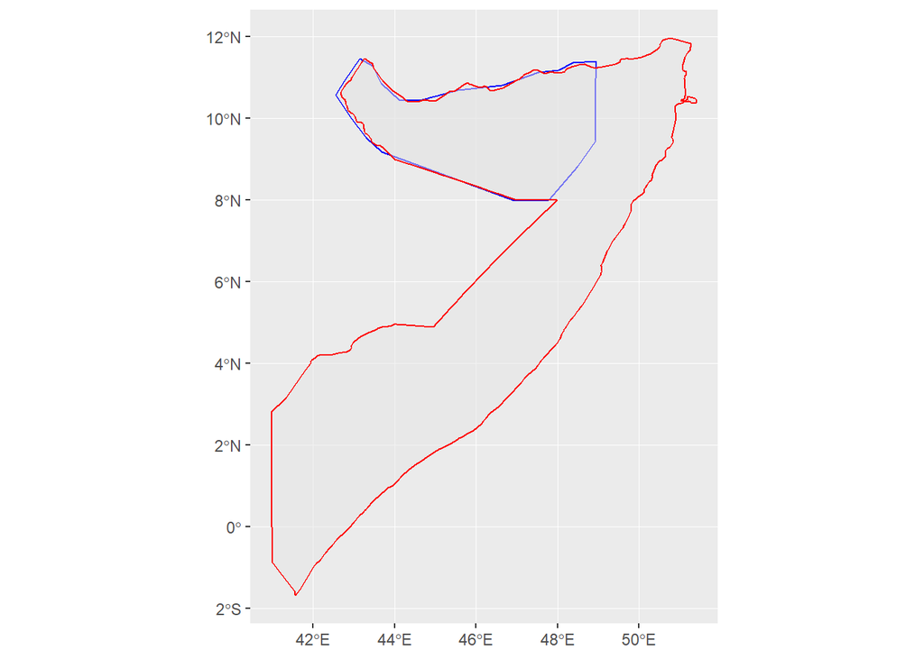

```r
somaliland <-
  countries %>%
  filter(SOVEREIGNT == "Somaliland") %>%
  extract2("geometry")
somalia <-
  cshp %>%
  filter(country == "Somalia") %>%
  extract2("geometry")
ggplot() +
  geom_sf(data = somaliland, alpha = .5, colour = "blue") +
  geom_sf(data = somalia, alpha = .5, colour = "red")
```

Due to the different sources, the borders around the part that is Somaliland have minor differences. Therefore, I define Somaliland as the intersection of Somalia and Somaliland and Somalia as Somalia without Somaliland.

```r
somaliland <- st_intersection(somalia, somaliland)
```

```
## although coordinates are longitude/latitude, st_intersection assumes that they are planar
```

```r
somalia <- st_difference(somalia, somaliland)
```

```
## although coordinates are longitude/latitude, st_difference assumes that they are planar
```

```r
cow_geocode <-
  cow_geocode %>%
  mutate(end_year = if_else(country_name == "Somalia",
                            1991,
                            end_year)) %>%
  rbind(
    st_sf(
      country_name = c("Somalia", "Somaliland"),
      country = c("Somalia", "Somaliland"),
      cow_code = c(520, NA_integer_),
      start_year = 1992,
      end_year = 2017,
      geometry = c(somalia, somaliland)
    ) %>%
      st_transform(crs = st_crs(cow_geocode))
  )
```

## Hongkong

We can find Hong Kong in the states dataset of “Natural Earth”.

```r
states <-
  read_sf(
    system.file(
      "extdata",
      "natural_earth/ne_10m_admin_1_states_provinces.shp",
      package = "vdem.tectr"
    )
  ) %>%
  st_transform(crs = st_crs(cow_geocode))
hongkong <-
  states %>%
  filter(iso_a2 == "HK") %>%
  extract2("geometry") %>%
  st_union()
cow_geocode <-
  cow_geocode %>%
  rbind(
    st_sf(
      country_name = "Hong Kong",
      country = "Hong Kong",
      cow_code = NA_integer_,
      start_year = 1946,
      end_year = 2017,
      geometry = hongkong
    )
  )
```

## Palestinian regions

Palestine under the british mandate is coded until 1948 and cooresponded to Israel and Palestine. We will first read in all regions in the area.

```r
british_mandate <-
  cow_geocode %>%
  filter(country_name == "Israel", end_year == 2017) %>%
  extract2("geometry")
westbank <-
  states %>%
  filter(name == "West Bank") %>%
  extract2("geometry")
gazastrip <-
  states %>%
  filter(name == "Gaza Strip") %>%
  extract2("geometry")
israels <-
  cow_geocode %>%
  filter(country_name == "Israel") %>%
  arrange(start_year) %>%
  extract2("geometry") %>%
  st_difference(st_union(westbank, gazastrip))
```

```
## although coordinates are longitude/latitude, st_union assumes that they are planar
```

```
## although coordinates are longitude/latitude, st_difference assumes that they are planar
```

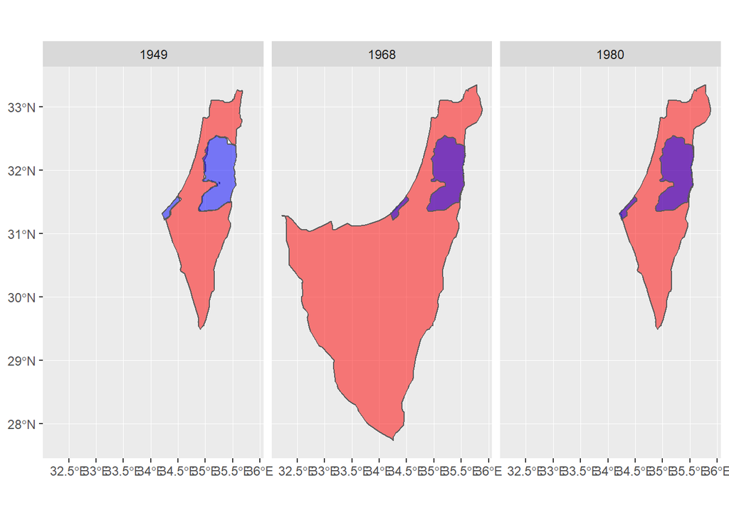

```r
cow_geocode %>%
  filter(country_name == "Israel") %>%
  ggplot() +
  geom_sf(fill = "red", alpha = .5) +
  geom_sf(data = c(westbank, gazastrip),
          alpha = .5, fill = "blue") +
  facet_wrap(vars(start_year))
```

According to the country coding document, West Bank refers to both West Bank and Gaza except for 1948 - 1967 and 2007 - 2017 when Gaza is coded separately. We thus implement this:

```r
cow_geocode <-
  cow_geocode %>%
  filter(country_name != "Israel") %>%
  rbind(
    st_sf(
      country_name =
        c("Palestine/British Mandate",
          "Israel", "Israel", "Israel",
          "Palestine/West Bank",
          "Palestine/West Bank",
          "Palestine/West Bank",
          "Palestine/Gaza",
          "Palestine/Gaza"),
      country =
        c("Palestine/British Mandate",
          "Israel", "Israel", "Israel",
          "Palestine/West Bank",
          "Palestine/West Bank",
          "Palestine/West Bank",
          "Palestine/Gaza",
          "Palestine/Gaza"),
      cow_code = c(NA_integer_, rep(666, 3), rep(NA_integer_, 5)),
      start_year =
        c(1946, 1949, 1968, 1980, 1949, 1968, 2008, 1948, 2007),
      end_year =
        c(1948, 1967, 1979, 2017, 1967, 2007, 2017, 1967, 2017),
      geometry =
        c(british_mandate,
          israels,
          westbank,
          st_union(westbank, gazastrip),
          westbank,
          gazastrip,
          gazastrip)
    )
  )
```

```
## although coordinates are longitude/latitude, st_union assumes that they are planar
```

This concludes the geocoding as all remaining regions have been coded. The country column is superfluous and we therefore delete it.

```r
vdem_spatial <-
  cow_geocode %>%
  select(-country)
devtools::use_data(vdem_spatial, overwrite = TRUE)
```

```
## Saving vdem_spatial as vdem_spatial.rda to C:/Users/samue/Documents/Studium/Statistik/vdem.tectr/data
```